# CCA

Florence Mehl

March 05, 2026

# Context and dataset introduction

This dataset originates from a nutrigenomic study in mice (Martin et al., 2007), designed to investigate how dietary fatty acid composition influences liver lipid profiles and hepatic gene expression.

**Experimental Design**

Forty mice were cross-classified according to two experimental factors, each with multiple levels:

- Genotype (2 levels):  
  Wild-type (WT)  
  PPARα knockout (PPARα -/-)
- Diet (5 levels):

REF: Reference diet (50/50 corn and colza oils)  
COC: Saturated fatty acid-rich diet (hydrogenated coconut oil)  
SUN: Omega-6-rich diet (sunflower oil)  
LIN: Omega-3-rich diet (linseed oil)  
FISH: Mixed diet (corn/colza/enriched fish oils in 43/43/14 ratio)

Each genotype-diet combination includes four biological replicates.

**Variables Collected**

Two sets of variables were measured for each mouse:

- Gene Expression:

Expression levels of 120 selected hepatic genes, chosen from ~30,000 candidates for their relevance to nutritional regulation.  
Measured using nylon macroarrays with radioactive labeling.

- Lipid Composition:

Relative concentrations (percentages) of 21 hepatic fatty acids.  
Quantified via gas chromatography.

```r
data("nutrimouse")
genes <- nutrimouse$gene
lipids <- nutrimouse$lipid
metadata <- data.frame(genotype = nutrimouse$genotype, diet = nutrimouse$diet)
metadata$sample_name <- paste0(rownames(metadata), "_", metadata$genotype, "_", metadata$diet)
rownames(genes) <- metadata$sample_name
rownames(lipids) <- metadata$sample_name
```

# 1.Basic CCA

note: The gene expression data is reduced to 15 genes so that the number of variables is less than the number of samples, to perform an unregularized CCA.

```r
nutrimouse$gene_selected <- nutrimouse$gene[,1:15]
str(nutrimouse$gene_selected)
```

```
## 'data.frame':    40 obs. of  15 variables:
##  $ X36b4: num  -0.42 -0.44 -0.48 -0.45 -0.42 -0.43 -0.53 -0.49 -0.36 -0.5 ...
##  $ ACAT1: num  -0.65 -0.68 -0.74 -0.69 -0.71 -0.69 -0.62 -0.69 -0.66 -0.62 ...
##  $ ACAT2: num  -0.84 -0.91 -1.1 -0.65 -0.54 -0.8 -1 -0.91 -0.74 -0.79 ...
##  $ ACBP : num  -0.34 -0.32 -0.46 -0.41 -0.38 -0.32 -0.44 -0.37 -0.39 -0.36 ...
##  $ ACC1 : num  -1.29 -1.23 -1.3 -1.26 -1.21 -1.13 -1.22 -1.29 -1.15 -1.21 ...
##  $ ACC2 : num  -1.13 -1.06 -1.09 -1.09 -0.89 -0.79 -1 -1.06 -1.08 -0.82 ...
##  $ ACOTH: num  -0.93 -0.99 -1.06 -0.93 -1 -0.93 -0.94 -1.05 -0.88 -0.92 ...
##  $ ADISP: num  -0.98 -0.97 -1.08 -1.02 -0.95 -0.97 -0.94 -1.02 -0.98 -0.99 ...
##  $ ADSS1: num  -1.19 -1 -1.18 -1.07 -1.08 -1.07 -1.05 -1.16 -1.05 -1 ...
##  $ ALDH3: num  -0.68 -0.62 -0.75 -0.71 -0.76 -0.75 -0.67 -0.75 -0.66 -0.69 ...
##  $ AM2R : num  -0.59 -0.58 -0.66 -0.65 -0.59 -0.55 -0.66 -0.66 -0.53 -0.62 ...
##  $ AOX  : num  -0.16 -0.12 -0.16 -0.17 -0.31 -0.23 -0.09 -0.22 -0.06 -0.23 ...
##  $ BACT : num  -0.22 -0.32 -0.32 -0.32 -0.31 -0.29 -0.25 -0.21 -0.15 -0.2 ...
##  $ BIEN : num  -0.89 -0.88 -0.89 -0.77 -0.97 -0.84 -0.86 -0.9 -0.74 -0.76 ...
##  $ BSEP : num  -0.69 -0.6 -0.7 -0.67 -0.68 -0.55 -0.67 -0.66 -0.6 -0.58 ...
```

```r
cca.res <- rcc(X=nutrimouse$gene_selected, Y=nutrimouse$lipid)
```

The sample distribution plot can be performed with **variates**, sample coordinates in the new reference (rotated axes) for each of the two blocks.

```r
cca.res_scores_genes <- data.frame(metadata, cca.res$variates$X)

cca.res_scores_lipids <- data.frame(metadata, cca.res$variates$Y)
```

## Plot the loadings

Variable relationship is obtained from **loadings** or with `plotVar`.

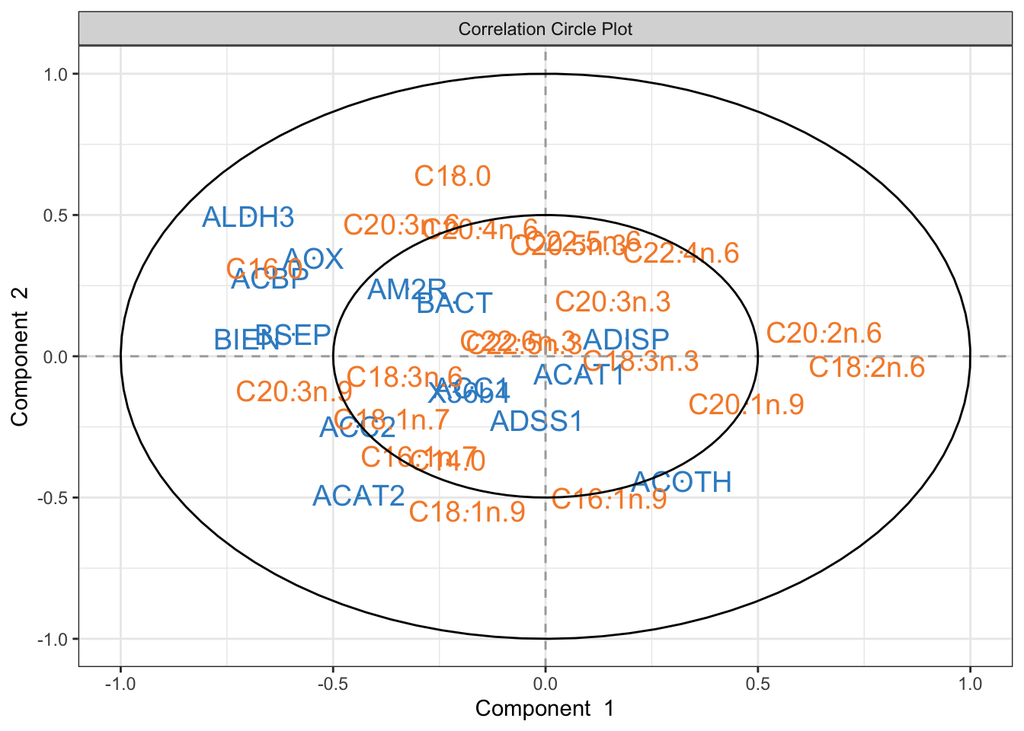

```r
cca.res_loadings_genes <- data.frame(cca.res$loadings$X)

cca.res_loadings_lipids <- data.frame(cca.res$loadings$Y)

plotVar(cca.res)
```

# 2.CCA on scaled data

- Perform CCA with scaled datasets and observe the difference with previous one

```r
cca.res.scale <- rcc(X=scale(nutrimouse$gene_selected, center=T, scale=T),
                     Y=scale(nutrimouse$lipid, center=T, scale=T), ncomp=2)
```

The sample distribution plot can be performed with **variates**, sample coordinates in the new reference (rotated axes) for each of the two blocks.

```r
cca.res.scale_scores_genes <- data.frame(metadata, cca.res.scale$variates$X)

cca.res.scale_scores_lipids <- data.frame(metadata, cca.res.scale$variates$Y)
```

## Plot the loadings

Variable relationship is obtained from **loadings** or with `plotVar`.

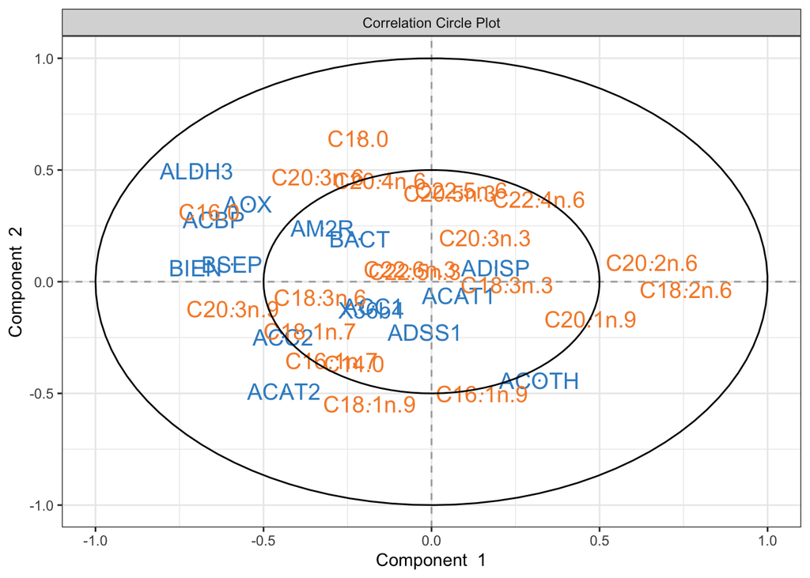

```r
cca.res.scale_loadings_genes <- data.frame(cca.res.scale$loadings$X)

cca.res.scale_loadings_lipids <- data.frame(cca.res.scale$loadings$Y)

plotVar(cca.res)
```

# 3.Regularized CCA

- Perform regularized CCA with all genes and lipids.

```r
rcca.res <- rcc(X=nutrimouse$gene, Y=nutrimouse$lipid, ncomp=2, method="shrinkage")
```

The sample distribution plot can be performed with **variates**, sample coordinates in the new reference (rotated axes) for each of the two blocks.

```r
rcca.res_scores_genes <- data.frame(metadata, rcca.res$variates$X)

rcca.res_scores_lipids <- data.frame(metadata, rcca.res$variates$Y)
```

## Plot the loadings

Variable relationship is obtained from **loadings** or with `plotVar`.

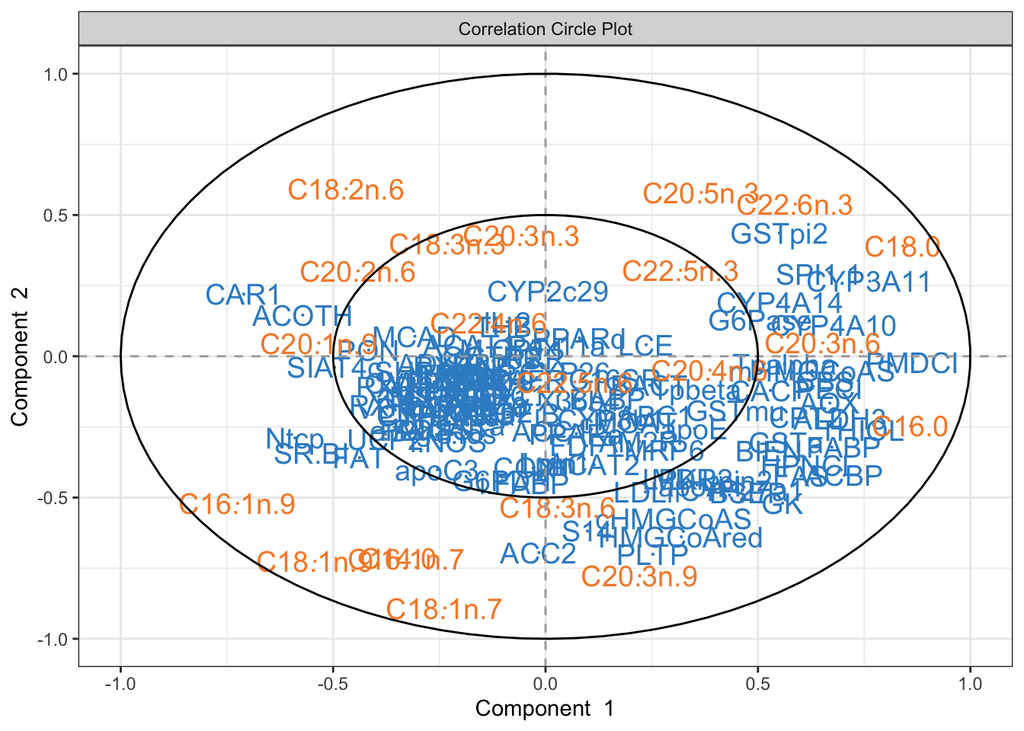

```r
rcca.res_loadings_genes <- data.frame(rcca.res$loadings$X)

rcca.res_loadings_lipids <- data.frame(rcca.res$loadings$Y)

plotVar(rcca.res)
```